# Norwegian CDI

Colin Ayres

December 10, 2024

We read data from “norwegian_cdi.csv” file. We only keep the “WG” subset (there are two age versions, “**W**ords & **G**estures” for younger and “**W**ords & **S**entences” for older children). We remove columns we don’t need, keeping only “child_id”, “age”, “comprehension”, “production”, “sex”, and “caregiver_education”.

```r
read.csv2("norwegian_cdi.csv") -> cdi
cdi[cdi$form == "WG",] -> cdi
subset(cdi, select = c(child_id, age, comprehension, production, sex, caregiver_education)) -> cdi
```

There are 2804 responses in total, with age ranging from 8 to 20 months.

Below is a scatterplot of *production* scores by age. Blue dots are female scores and pink dots are male scores.

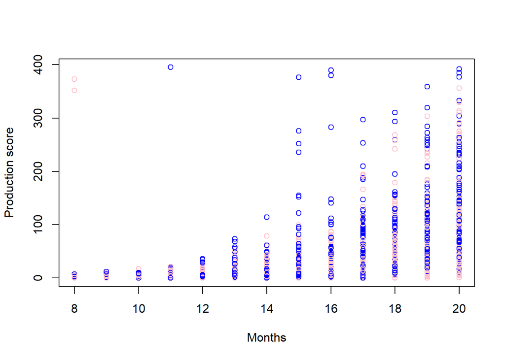

```r
# "col" argument (below) can take a single value, e.g., "red",
# or a whole vector of values, e.g., specifing colour for each dot.
plot(cdi$age, cdi$production,
     col = ifelse(cdi$sex == "Male", "pink", "blue"),
     xlab = "Months", ylab = "Production score")
```

We focus now on the oldest group. There are 259 children in this group. The bounds of the 95% CI for the true (population) mean of *comprehension* scores for them is printed below:

```r
mean(cdi[cdi$age==20,]$comprehension, na.rm = TRUE) -> xbar
sd(cdi[cdi$age==20,]$comprehension, na.rm = TRUE) -> sd
nrow(cdi[cdi$age==20,]) -> n
xbar + qt(c(.025, 0.975), n-1) * sd / sqrt(n) -> cdi20_comprehension
cdi20_comprehension
```

```
## [1] 235.6691 256.3618
```

The bounds of the 95% CI for the true (population) mean of *production* scores for them is printed below:

```r
mean(cdi[cdi$age==20,]$production, na.rm = TRUE) -> xbar
sd(cdi[cdi$age==20,]$production, na.rm = TRUE) -> sd
nrow(cdi[cdi$age==20,]) -> n
xbar + qt(c(.025, 0.975), n-1) * sd / sqrt(n) -> cdi20_production
cdi20_production
```

```
## [1]  94.36622 115.68783
```

## Bonus

We also calculate the *comprehension* CIs for girls and boys (in the oldest group).

> It’s not obligatory! Don’t worry, if you can’t work out how to use `tapply()` below, but please remember to set `eval` to `FALSE` for the chunk in that case, so that the document knits even without working code below.

```r
# tapply() splits a vector given as the first argument,
# using vector(s) given as the second argument,
# and to each part of the original vector applies a function
# given as the third argument.
tapply(cdi[cdi$age==20,]$comprehension, cdi[cdi$age==20,]$sex, function(x) {
    mean(x) + qt(c(0.025, 0.975), length(x) - 1) * sd(x) / sqrt(length(x))
})
```

```
## $Female
## [1] 238.4194 266.8179
##
## $Male
## [1] 225.5608 255.4179
```